# developmental_brainage_analysis

load libraries

```r
library(ggplot2)
library(readr)
library(readxl)
library(rstatix)
library(broom)
library(stringr)
library(dplyr)
```

load files

```r
#Male data
MR_predicted_age_male <- read_csv("/KIMEL/tigrlab/scratch/jshah/brain_age_analysis/data/processed/full_developmental_output/output_file_2024-10-28-00-45-29_MR_predicted_age_male.csv", show_col_types = FALSE)
BrainAGE_male <- read_csv("/KIMEL/tigrlab/scratch/jshah/brain_age_analysis/data/processed/full_developmental_output/output_file_2024-10-28-00-45-29_BrainAGE_male.csv", show_col_types = FALSE)
Adjusted_MR_predicted_age_male <- read_csv("/KIMEL/tigrlab/scratch/jshah/brain_age_analysis/data/processed/full_developmental_output/output_file_2024-10-28-00-45-29_Adjusted_MR_predicted_age_male.csv", show_col_types = FALSE)
Adjusted_BrainAGE_male <- read_csv("/KIMEL/tigrlab/scratch/jshah/brain_age_analysis/data/processed/full_developmental_output/output_file_2024-10-28-00-45-29_Adjusted_BrainAGE_male.csv", show_col_types = FALSE)
#Female data
MR_predicted_age_female <- read_csv("/KIMEL/tigrlab/scratch/jshah/brain_age_analysis/data/processed/full_developmental_output/output_file_2024-10-28-00-40-48_MR_predicted_age_female.csv", show_col_types = FALSE)
BrainAGE_female <- read_csv("/KIMEL/tigrlab/scratch/jshah/brain_age_analysis/data/processed/full_developmental_output/output_file_2024-10-28-00-40-48_BrainAGE_female.csv", show_col_types = FALSE)
Adjusted_MR_predicted_age_female <- read_csv("/KIMEL/tigrlab/scratch/jshah/brain_age_analysis/data/processed/full_developmental_output/output_file_2024-10-28-00-40-48_Adjusted_MR_predicted_age_female.csv", show_col_types = FALSE)
Adjusted_BrainAGE_female <- read_csv("/KIMEL/tigrlab/scratch/jshah/brain_age_analysis/data/processed/full_developmental_output/output_file_2024-10-28-00-40-48_Adjusted_BrainAGE_female.csv", show_col_types = FALSE)
#Load euler's number

euler_data <- read_tsv("/KIMEL/tigrlab/scratch/jshah/brain_age_analysis/data/raw/00_group2_stats_tables/euler.tsv")
```

```r
#Load male template because it has real age

male_developmental_template <- read_csv("/KIMEL/tigrlab/scratch/jshah/brain_age_analysis/data/processed/male_subID_developmental_template.csv", show_col_types = FALSE)

#Load female template because it has real age and subject ID

female_developmental_template <- read_csv("/KIMEL/tigrlab/scratch/jshah/brain_age_analysis/data/processed/female_subID_developmental_template.csv", show_col_types = FALSE)

#Load TAY demographic data to get PSS

tay_demo <- read_csv("/KIMEL/tigrlab/scratch/jshah/brain_age_analysis/data/raw/tay_mri_demo_summer2024.csv", show_col_types = FALSE)

#Load data cut file
datacut_ids <- read_csv("/KIMEL/tigrlab/scratch/jshah/brain_age_analysis/data/raw/datacut_ids.csv")
```

Function to clean demographic subject_IDs

```r
clean_subject_ids_demo <- function(df, subject_id) {
  df %>%
    mutate(clean_subject_id = str_extract(!!sym(subject_id), "[0-9]{8}$"))
}
```

Use the function to clean the demographic subject ids

```r
TAY_demographics <- clean_subject_ids_demo(tay_demo, "subject_id")

datacut_ids_clean <- clean_subject_ids_demo(datacut_ids, "subject_id")

female_developmental_template <- female_developmental_template %>%
  rename(clean_subject_id = subject_id)

female_developmental_template <- female_developmental_template %>%
  mutate(sex = "Female")

male_developmental_template <- male_developmental_template %>%
  rename(clean_subject_id = subject_id)

male_developmental_template <- male_developmental_template %>%
  mutate(sex = "Male")
```

clean subject IDs for the euler_data file

```r
clean_subject_ids_tsv <- function(df) {
  colnames(df)[1] <- "clean_subject_id"  # Rename the first column to 'clean_subject_id'
  df %>%
    mutate(clean_subject_id = str_extract(clean_subject_id, "[0-9]{8}$"))  # Extract the last 8 digits of subject IDs
}

euler_data_clean <- clean_subject_ids_tsv(euler_data)

print(euler_data_clean)
```

```
## # A tibble: 551 × 4
##    clean_subject_id lh_euler rh_euler mean_euler_bh
##    <chr>               <dbl>    <dbl>         <dbl>
##  1 00000001              -74      -34           -54
##  2 00000003              -52      -54           -53
##  3 00000004              -92     -134          -113
##  4 00000005              -88      -74           -81
##  5 00000007              -34      -58           -46
##  6 00000008              -50      -46           -48
##  7 00000009              -50      -66           -58
##  8 00000013              -82     -110           -96
##  9 00000016              -72      -56           -64
## 10 00000017              -78      -74           -76
## # ℹ 541 more rows
```

filtered for participant rows that have prodromal psychosis because not all participants have prodromal psychosis listed at T1

```r
# Group by subject ID and prioritize rows where symptoms are filled out
# If symptoms are NA, the function will pick the first occurrence that has them filled
TAY_unique_symptoms <- TAY_demographics %>%
  group_by(clean_subject_id) %>%
  arrange(desc(!is.na(prodromal_psychosis))) %>%  # Arrange to prioritize rows where symptoms are NOT NA
  slice(1) %>%  # Keep the first row per subject (the one with symptoms, if available)
  ungroup()

# The result will be a dataframe with unique subject IDs and prioritized symptom data
print(TAY_unique_symptoms)
```

```
## # A tibble: 582 × 11
##    subject_id      time_point assigned_sex_at_birth age_scan prodromal_psychosis
##    <chr>           <chr>      <chr>                    <dbl> <lgl>
##  1 TAY01_CMH_0000… 01         Female                    13.8 FALSE
##  2 TAY01_CMH_0000… 05         Male                      18.4 FALSE
##  3 TAY01_CMH_0000… 01         Female                    15.3 TRUE
##  4 TAY01_CMH_0000… 01         Male                      15.1 FALSE
##  5 TAY01_CMH_0000… 01         Male                      12.4 FALSE
##  6 TAY01_CMH_0000… 03         <NA>                      17.6 FALSE
##  7 TAY01_CMH_0000… 01         Female                    16.2 FALSE
##  8 TAY01_CMH_0000… 01         Female                    17.1 FALSE
##  9 TAY01_CMH_0000… 01         Female                    13.6 TRUE
## 10 TAY01_CMH_0000… 03         <NA>                      25.3 FALSE
## # ℹ 572 more rows
## # ℹ 6 more variables: prime_total <dbl>, `SRSSF total score (Youth)` <dbl>,
## #   `SRSSF total score (Caregiver)` <dbl>, `Clinical diagnosis of ASD` <chr>,
## #   `Meet criteria for ASD on KSADS` <chr>, clean_subject_id <chr>
```

Create a new dataframe with subject IDs from the female template, and age. Then import the PSS/non-PSS from the TAY demographics using the matching subject IDs.

```r
# Step 1: Extract subject ID and age from female_developmental_template
female_data <- female_developmental_template %>%
  select(clean_subject_id, AGE, sex)  # Assuming 'clean_subject_id' and 'age' are the column names

# Step 2: Use left_join to get sex and PSS from TAY_demographics
# Assuming 'TAY_demographics' has columns 'clean_subject_id', 'assigned_sex_at_birth', and 'prodromal_psychosis'
final_analysis_female_data <- female_data %>%
  left_join(TAY_unique_symptoms %>%
              select(clean_subject_id, prodromal_psychosis),  # Select relevant columns
            by = "clean_subject_id")  # Merge by subject ID

print(final_analysis_female_data)
```

```
## # A tibble: 335 × 4
##    clean_subject_id   AGE sex    prodromal_psychosis
##    <chr>            <dbl> <chr>  <lgl>
##  1 00000003          15.3 Female TRUE
##  2 00000007          16.2 Female FALSE
##  3 00000008          17.1 Female FALSE
##  4 00000009          13.6 Female TRUE
##  5 00000013          15.7 Female TRUE
##  6 00000017          20.0 Female FALSE
##  7 00000019          11.2 Female FALSE
##  8 00000025          19.0 Female FALSE
##  9 00000027          17.0 Female TRUE
## 10 00000028          19.6 Female TRUE
## # ℹ 325 more rows
```

Do the same for the male participants

```r
# Step 1: Extract subject ID and age from female_developmental_template
male_data <- male_developmental_template %>%
  select(clean_subject_id, AGE, sex)  # Assuming 'clean_subject_id' and 'age' are the column names

# Step 2: Use left_join to get sex and PSS from TAY_demographics
# Assuming 'TAY_demographics' has columns 'clean_subject_id', 'assigned_sex_at_birth', and 'prodromal_psychosis'
final_analysis_male_data <- male_data %>%
  left_join(TAY_unique_symptoms %>%
              select(clean_subject_id, prodromal_psychosis),  # Select relevant columns
            by = "clean_subject_id")  # Merge by subject ID

print(final_analysis_male_data)
```

```
## # A tibble: 193 × 4
##    clean_subject_id   AGE sex   prodromal_psychosis
##    <chr>            <dbl> <chr> <lgl>
##  1 00000004          15.1 Male  FALSE
##  2 00000005          12.4 Male  FALSE
##  3 00000016          15.8 Male  TRUE
##  4 00000020          12.5 Male  FALSE
##  5 00000021          17.8 Male  TRUE
##  6 00000023          16.8 Male  FALSE
##  7 00000024          24.8 Male  TRUE
##  8 00000033          24.2 Male  FALSE
##  9 00000036          17.9 Male  FALSE
## 10 00000039          12.5 Male  FALSE
## # ℹ 183 more rows
```

Add the brain age calculator output. This includes female_age, female_error, corage_female, female_adjerror

```r
final_analysis_female_data<- final_analysis_female_data %>%
  mutate(female_age = MR_predicted_age_female$female_age,
         female_error = BrainAGE_female$female_error,
         corage_female = Adjusted_MR_predicted_age_female$corage_female,
         female_adjerror = Adjusted_BrainAGE_female$female_adjerror)

# Rename the columns
final_analysis_female_data <- final_analysis_female_data %>%
  rename(
    predicted_age = female_age,
    BrainAGE = female_error,
    Adjusted_predicted_age = corage_female,
    Adjusted_BrainAGE = female_adjerror
  )

# Print the updated dataframe to check the new column names
print(final_analysis_female_data)
```

```
## # A tibble: 335 × 8
##    clean_subject_id   AGE sex    prodromal_psychosis predicted_age BrainAGE
##    <chr>            <dbl> <chr>  <lgl>                       <dbl>    <dbl>
##  1 00000003          15.3 Female TRUE                         16.2    0.890
##  2 00000007          16.2 Female FALSE                        17.2    1.03
##  3 00000008          17.1 Female FALSE                        16.0   -1.09
##  4 00000009          13.6 Female TRUE                         14.7    1.11
##  5 00000013          15.7 Female TRUE                         13.1   -2.61
##  6 00000017          20.0 Female FALSE                        20.7    0.733
##  7 00000019          11.2 Female FALSE                        10.8   -0.445
##  8 00000025          19.0 Female FALSE                        14.7   -4.30
##  9 00000027          17.0 Female TRUE                         16.3   -0.631
## 10 00000028          19.6 Female TRUE                         17.5   -2.05
## # ℹ 325 more rows
## # ℹ 2 more variables: Adjusted_predicted_age <dbl>, Adjusted_BrainAGE <dbl>
```

Add brain age calculations for male data

```r
final_analysis_male_data<- final_analysis_male_data %>%
  mutate(male_age = MR_predicted_age_male$male_age,
         male_error = BrainAGE_male$male_error,
         corage_male = Adjusted_MR_predicted_age_male$corage_male,
         male_adjerror = Adjusted_BrainAGE_male$male_adjerror)

# Rename the columns
final_analysis_male_data <- final_analysis_male_data %>%
  rename(
    predicted_age = male_age,
    BrainAGE = male_error,
    Adjusted_predicted_age = corage_male,
    Adjusted_BrainAGE = male_adjerror
  )

print(final_analysis_male_data)
```

```
## # A tibble: 193 × 8
##    clean_subject_id   AGE sex   prodromal_psychosis predicted_age BrainAGE
##    <chr>            <dbl> <chr> <lgl>                       <dbl>    <dbl>
##  1 00000004          15.1 Male  FALSE                        16.4    1.31
##  2 00000005          12.4 Male  FALSE                        11.6   -0.765
##  3 00000016          15.8 Male  TRUE                         17.5    1.72
##  4 00000020          12.5 Male  FALSE                        NA     NA
##  5 00000021          17.8 Male  TRUE                         18.2    0.389
##  6 00000023          16.8 Male  FALSE                        15.5   -1.25
##  7 00000024          24.8 Male  TRUE                         16.6   -8.22
##  8 00000033          24.2 Male  FALSE                        15.2   -8.98
##  9 00000036          17.9 Male  FALSE                        16.2   -1.67
## 10 00000039          12.5 Male  FALSE                        11.4   -1.14
## # ℹ 183 more rows
## # ℹ 2 more variables: Adjusted_predicted_age <dbl>, Adjusted_BrainAGE <dbl>
```

combine the female and male data to create one dataframe to work with

```r
combined_analysis_data <- rbind(final_analysis_female_data, final_analysis_male_data)

print(combined_analysis_data)
```

```
## # A tibble: 528 × 8
##    clean_subject_id   AGE sex    prodromal_psychosis predicted_age BrainAGE
##    <chr>            <dbl> <chr>  <lgl>                       <dbl>    <dbl>
##  1 00000003          15.3 Female TRUE                         16.2    0.890
##  2 00000007          16.2 Female FALSE                        17.2    1.03
##  3 00000008          17.1 Female FALSE                        16.0   -1.09
##  4 00000009          13.6 Female TRUE                         14.7    1.11
##  5 00000013          15.7 Female TRUE                         13.1   -2.61
##  6 00000017          20.0 Female FALSE                        20.7    0.733
##  7 00000019          11.2 Female FALSE                        10.8   -0.445
##  8 00000025          19.0 Female FALSE                        14.7   -4.30
##  9 00000027          17.0 Female TRUE                         16.3   -0.631
## 10 00000028          19.6 Female TRUE                         17.5   -2.05
## # ℹ 518 more rows
## # ℹ 2 more variables: Adjusted_predicted_age <dbl>, Adjusted_BrainAGE <dbl>
```

Add euler’s number to the combined_analysis_data and join based on subject ID

```r
combined_analysis_data <- combined_analysis_data %>%
  left_join(euler_data_clean %>%
              select(clean_subject_id, mean_euler_bh),  # Select relevant columns
            by = "clean_subject_id")  # Merge by subject ID

print(combined_analysis_data)
```

```
## # A tibble: 528 × 9
##    clean_subject_id   AGE sex    prodromal_psychosis predicted_age BrainAGE
##    <chr>            <dbl> <chr>  <lgl>                       <dbl>    <dbl>
##  1 00000003          15.3 Female TRUE                         16.2    0.890
##  2 00000007          16.2 Female FALSE                        17.2    1.03
##  3 00000008          17.1 Female FALSE                        16.0   -1.09
##  4 00000009          13.6 Female TRUE                         14.7    1.11
##  5 00000013          15.7 Female TRUE                         13.1   -2.61
##  6 00000017          20.0 Female FALSE                        20.7    0.733
##  7 00000019          11.2 Female FALSE                        10.8   -0.445
##  8 00000025          19.0 Female FALSE                        14.7   -4.30
##  9 00000027          17.0 Female TRUE                         16.3   -0.631
## 10 00000028          19.6 Female TRUE                         17.5   -2.05
## # ℹ 518 more rows
## # ℹ 3 more variables: Adjusted_predicted_age <dbl>, Adjusted_BrainAGE <dbl>,
## #   mean_euler_bh <dbl>
```

Filter for people who are in the TAY data cut

```r
# Assuming 'sub_ID' is the column to match in both data frames and that `t01` is a logical or character column.
combined_analysis_data <- combined_analysis_data %>%
  # Join with datacut_ids_clean to bring in the 't01' column
  left_join(datacut_ids_clean %>% select(clean_subject_id, t01), by = "clean_subject_id")

# View the result
print(combined_analysis_data)
```

```
## # A tibble: 528 × 10
##    clean_subject_id   AGE sex    prodromal_psychosis predicted_age BrainAGE
##    <chr>            <dbl> <chr>  <lgl>                       <dbl>    <dbl>
##  1 00000003          15.3 Female TRUE                         16.2    0.890
##  2 00000007          16.2 Female FALSE                        17.2    1.03
##  3 00000008          17.1 Female FALSE                        16.0   -1.09
##  4 00000009          13.6 Female TRUE                         14.7    1.11
##  5 00000013          15.7 Female TRUE                         13.1   -2.61
##  6 00000017          20.0 Female FALSE                        20.7    0.733
##  7 00000019          11.2 Female FALSE                        10.8   -0.445
##  8 00000025          19.0 Female FALSE                        14.7   -4.30
##  9 00000027          17.0 Female TRUE                         16.3   -0.631
## 10 00000028          19.6 Female TRUE                         17.5   -2.05
## # ℹ 518 more rows
## # ℹ 4 more variables: Adjusted_predicted_age <dbl>, Adjusted_BrainAGE <dbl>,
## #   mean_euler_bh <dbl>, t01 <lgl>
```

```r
datacut_filtered_data <- combined_analysis_data %>%
  filter(t01 == TRUE)

# View the result
print(datacut_filtered_data)
```

```
## # A tibble: 441 × 10
##    clean_subject_id   AGE sex    prodromal_psychosis predicted_age BrainAGE
##    <chr>            <dbl> <chr>  <lgl>                       <dbl>    <dbl>
##  1 00000003          15.3 Female TRUE                         16.2    0.890
##  2 00000007          16.2 Female FALSE                        17.2    1.03
##  3 00000008          17.1 Female FALSE                        16.0   -1.09
##  4 00000009          13.6 Female TRUE                         14.7    1.11
##  5 00000013          15.7 Female TRUE                         13.1   -2.61
##  6 00000017          20.0 Female FALSE                        20.7    0.733
##  7 00000019          11.2 Female FALSE                        10.8   -0.445
##  8 00000025          19.0 Female FALSE                        14.7   -4.30
##  9 00000027          17.0 Female TRUE                         16.3   -0.631
## 10 00000028          19.6 Female TRUE                         17.5   -2.05
## # ℹ 431 more rows
## # ℹ 4 more variables: Adjusted_predicted_age <dbl>, Adjusted_BrainAGE <dbl>,
## #   mean_euler_bh <dbl>, t01 <lgl>
```

Remove high euler number (cut off above 200)

```r
euler_filtered_data <- datacut_filtered_data %>%
  filter(mean_euler_bh >= -200)

print(euler_filtered_data)
```

```
## # A tibble: 434 × 10
##    clean_subject_id   AGE sex    prodromal_psychosis predicted_age BrainAGE
##    <chr>            <dbl> <chr>  <lgl>                       <dbl>    <dbl>
##  1 00000003          15.3 Female TRUE                         16.2    0.890
##  2 00000007          16.2 Female FALSE                        17.2    1.03
##  3 00000008          17.1 Female FALSE                        16.0   -1.09
##  4 00000009          13.6 Female TRUE                         14.7    1.11
##  5 00000013          15.7 Female TRUE                         13.1   -2.61
##  6 00000017          20.0 Female FALSE                        20.7    0.733
##  7 00000019          11.2 Female FALSE                        10.8   -0.445
##  8 00000025          19.0 Female FALSE                        14.7   -4.30
##  9 00000027          17.0 Female TRUE                         16.3   -0.631
## 10 00000028          19.6 Female TRUE                         17.5   -2.05
## # ℹ 424 more rows
## # ℹ 4 more variables: Adjusted_predicted_age <dbl>, Adjusted_BrainAGE <dbl>,
## #   mean_euler_bh <dbl>, t01 <lgl>
```

View all NAs

```r
rows_with_na_develop <- euler_filtered_data %>%
  filter(if_any(everything(), is.na))
sum(is.na(euler_filtered_data$prodromal_psychosis))
```

```
## [1] 16
```

```r
print(rows_with_na_develop)
```

```
## # A tibble: 16 × 10
##    clean_subject_id   AGE sex    prodromal_psychosis predicted_age BrainAGE
##    <chr>            <dbl> <chr>  <lgl>                       <dbl>    <dbl>
##  1 00000162          20.5 Female NA                           19.5   -1.03
##  2 00000185          20.0 Female NA                           17.6   -2.31
##  3 00000493          17.4 Female NA                           14.4   -3.03
##  4 00000498          12.8 Female NA                           12.5   -0.293
##  5 00000523          24.6 Female NA                           20.2   -4.46
##  6 00000548          21.3 Female NA                           19.0   -2.27
##  7 00000552          19.6 Female NA                           16.4   -3.15
##  8 00000581          23.8 Female NA                           17.5   -6.28
##  9 00000594          20.2 Female NA                           15.7   -4.53
## 10 00000624          20.6 Female NA                           16.5   -4.10
## 11 00000664          18.7 Female NA                           15.3   -3.36
## 12 00000674          13.3 Female NA                           12.7   -0.659
## 13 00000466          17.6 Male   NA                           14.7   -2.84
## 14 00000578          17.7 Male   NA                           18.3    0.610
## 15 00000638          17.5 Male   NA                           14.5   -3.02
## 16 00000679          21.7 Male   NA                           18.8   -2.98
## # ℹ 4 more variables: Adjusted_predicted_age <dbl>, Adjusted_BrainAGE <dbl>,
## #   mean_euler_bh <dbl>, t01 <lgl>
```

```r
cleaned_filtered_data <- na.omit(euler_filtered_data)

print(cleaned_filtered_data)
```

```
## # A tibble: 418 × 10
##    clean_subject_id   AGE sex    prodromal_psychosis predicted_age BrainAGE
##    <chr>            <dbl> <chr>  <lgl>                       <dbl>    <dbl>
##  1 00000003          15.3 Female TRUE                         16.2    0.890
##  2 00000007          16.2 Female FALSE                        17.2    1.03
##  3 00000008          17.1 Female FALSE                        16.0   -1.09
##  4 00000009          13.6 Female TRUE                         14.7    1.11
##  5 00000013          15.7 Female TRUE                         13.1   -2.61
##  6 00000017          20.0 Female FALSE                        20.7    0.733
##  7 00000019          11.2 Female FALSE                        10.8   -0.445
##  8 00000025          19.0 Female FALSE                        14.7   -4.30
##  9 00000027          17.0 Female TRUE                         16.3   -0.631
## 10 00000028          19.6 Female TRUE                         17.5   -2.05
## # ℹ 408 more rows
## # ℹ 4 more variables: Adjusted_predicted_age <dbl>, Adjusted_BrainAGE <dbl>,
## #   mean_euler_bh <dbl>, t01 <lgl>
```

Run summary statistics

```r
summary(cleaned_filtered_data)
```

```
##  clean_subject_id        AGE            sex            prodromal_psychosis
##  Length:418         Min.   :11.13   Length:418         Mode :logical
##  Class :character   1st Qu.:15.64   Class :character   FALSE:204
##  Mode  :character   Median :17.93   Mode  :character   TRUE :214
##                     Mean   :18.40
##                     3rd Qu.:21.65
##                     Max.   :25.27
##  predicted_age      BrainAGE        Adjusted_predicted_age Adjusted_BrainAGE
##  Min.   :10.43   Min.   :-9.24062   Min.   :10.30          Min.   :-5.6645
##  1st Qu.:15.14   1st Qu.:-4.07382   1st Qu.:16.10          1st Qu.:-1.7446
##  Median :16.49   Median :-1.55237   Median :18.24          Median :-0.1651
##  Mean   :16.36   Mean   :-2.03727   Mean   :18.06          Mean   :-0.3426
##  3rd Qu.:17.95   3rd Qu.: 0.01955   3rd Qu.:20.39          3rd Qu.: 1.1313
##  Max.   :20.92   Max.   : 7.04516   Max.   :24.58          Max.   : 7.1065
##  mean_euler_bh       t01
##  Min.   :-167.00   Mode:logical
##  1st Qu.: -67.00   TRUE:418
##  Median : -53.00
##  Mean   : -56.24
##  3rd Qu.: -39.25
##  Max.   : -15.00
```

```r
table(cleaned_filtered_data$sex)
```

```
##
## Female   Male
##    274    144
```

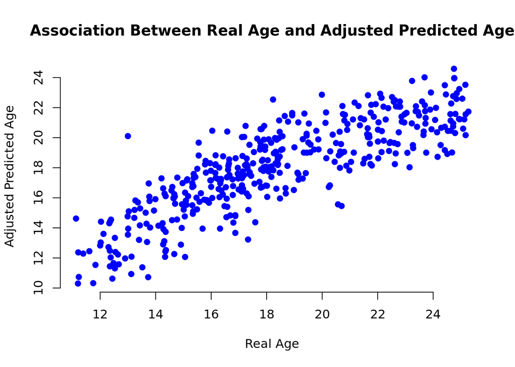

```r
plot(cleaned_filtered_data$AGE, cleaned_filtered_data$Adjusted_predicted_age, main = "Association Between Real Age and Adjusted Predicted Age",
     xlab = "Real Age", ylab = "Adjusted Predicted Age",
     pch = 19, frame = FALSE, col = "blue")
```

```r
cor.test(cleaned_filtered_data$AGE, cleaned_filtered_data$Adjusted_predicted_age, method = 'pearson')
```

```
##
##  Pearson's product-moment correlation
##
## data:  cleaned_filtered_data$AGE and cleaned_filtered_data$Adjusted_predicted_age
## t = 31.122, df = 416, p-value < 2.2e-16
## alternative hypothesis: true correlation is not equal to 0
## 95 percent confidence interval:
##  0.8050569 0.8630664
## sample estimates:
##       cor
## 0.8363885
```

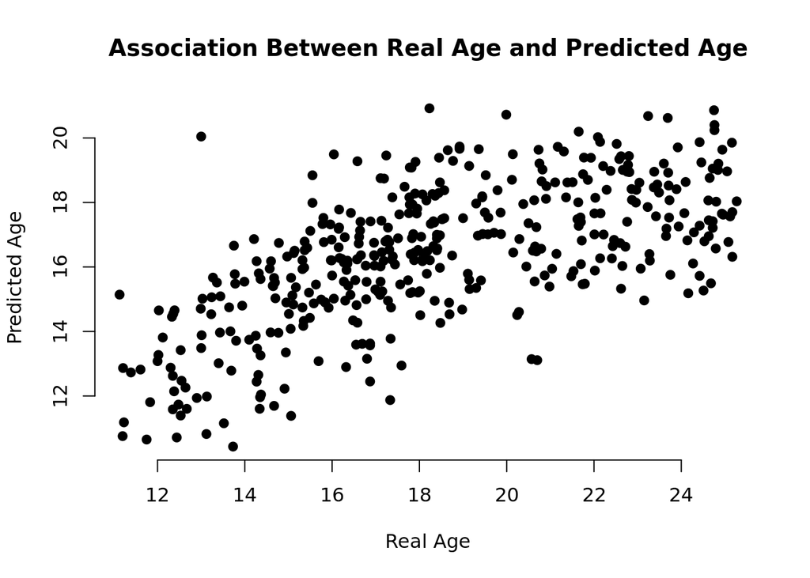

```r
plot(cleaned_filtered_data$AGE, cleaned_filtered_data$predicted_age, main = "Association Between Real Age and Predicted Age",
     xlab = "Real Age", ylab = "Predicted Age",
     pch = 19, frame = FALSE)
```

```r
cor.test(cleaned_filtered_data$AGE, cleaned_filtered_data$predicted_age, method = 'pearson')
```

```
##
##  Pearson's product-moment correlation
##
## data:  cleaned_filtered_data$AGE and cleaned_filtered_data$predicted_age
## t = 17.34, df = 416, p-value < 2.2e-16
## alternative hypothesis: true correlation is not equal to 0
## 95 percent confidence interval:
##  0.5883700 0.7001481
## sample estimates:
##       cor
## 0.6477313
```

Run linear regression between predicted age and psychosis symptoms

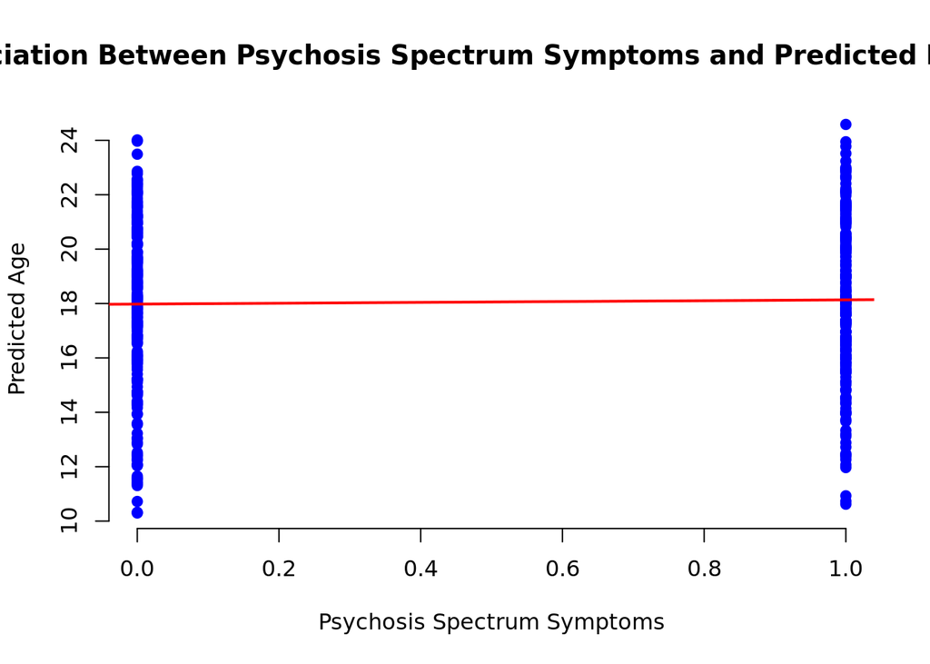

```r
plot(cleaned_filtered_data$prodromal_psychosis, cleaned_filtered_data$Adjusted_predicted_age,
     main = "Association Between Psychosis Spectrum Symptoms and Predicted BrainAGE",
     xlab = "Psychosis Spectrum Symptoms", ylab = "Predicted Age",
     pch = 19, frame = FALSE, col = "blue")

# Run a linear regression analysis
lm_model <- lm(Adjusted_predicted_age ~ prodromal_psychosis, data = cleaned_filtered_data)

# Add the regression line to the plot
abline(lm_model, col = "red", lwd = 2)
```

```r
# Print the linear regression model summary
summary(lm_model)
```

```
##
## Call:
## lm(formula = Adjusted_predicted_age ~ prodromal_psychosis, data = cleaned_filtered_data)
##
## Residuals:
##     Min      1Q  Median      3Q     Max
## -7.6822 -1.9180  0.1551  2.2600  6.4502
##
## Coefficients:
##                         Estimate Std. Error t value Pr(>|t|)
## (Intercept)              17.9795     0.2102  85.534   <2e-16 ***
## prodromal_psychosisTRUE   0.1550     0.2938   0.527    0.598
## ---
## Signif. codes:  0 '***' 0.001 '**' 0.01 '*' 0.05 '.' 0.1 ' ' 1
##
## Residual standard error: 3.002 on 416 degrees of freedom
## Multiple R-squared:  0.0006683,  Adjusted R-squared:  -0.001734
## F-statistic: 0.2782 on 1 and 416 DF,  p-value: 0.5982
```

Run regression analysis for BrainAGE and PSS

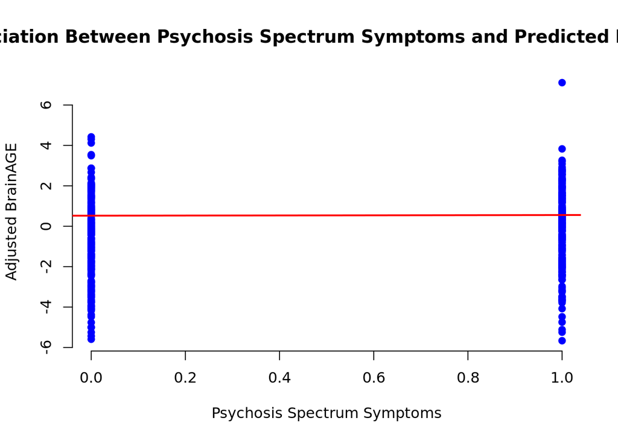

```r
plot(cleaned_filtered_data$prodromal_psychosis, cleaned_filtered_data$Adjusted_BrainAGE,
     main = "Association Between Psychosis Spectrum Symptoms and Predicted BrainAGE",
     xlab = "Psychosis Spectrum Symptoms", ylab = "Adjusted BrainAGE",
     pch = 19, frame = FALSE, col = "blue")

# Run a linear regression analysis
lm_model <- lm(prodromal_psychosis ~ Adjusted_BrainAGE, data = cleaned_filtered_data)

# Add the regression line to the plot
abline(lm_model, col = "red", lwd = 2)
```

```r
# Print the linear regression model summary
summary(lm_model)
```

```
##
## Call:
## lm(formula = prodromal_psychosis ~ Adjusted_BrainAGE, data = cleaned_filtered_data)
##
## Residuals:
##     Min      1Q  Median      3Q     Max
## -0.6637 -0.5103  0.3813  0.4749  0.6575
##
## Coefficients:
##                   Estimate Std. Error t value Pr(>|t|)
## (Intercept)        0.52288    0.02465  21.212  < 2e-16 ***
## Adjusted_BrainAGE  0.03185    0.01202   2.649  0.00838 **
## ---
## Signif. codes:  0 '***' 0.001 '**' 0.01 '*' 0.05 '.' 0.1 ' ' 1
##
## Residual standard error: 0.4969 on 416 degrees of freedom
## Multiple R-squared:  0.01659,    Adjusted R-squared:  0.01423
## F-statistic: 7.018 on 1 and 416 DF,  p-value: 0.008376
```

Run multivariable regression with PSS as the independent variable and predicted brainage as the dependent variable

```r
run_lm_model <- function(dependent_var, independent_vars, data) {
  # Create a formula dynamically
  formula <- as.formula(paste(dependent_var, "~", paste(independent_vars, collapse = " + ")))

  # Run the linear model with the formula and the data explicitly specified
  lm_model <- lm(formula, data = data)

  # Print summary of the model
  return(summary(lm_model))
}

dependent_vars <- c("Adjusted_predicted_age", "Adjusted_BrainAGE", "predicted_age", "BrainAGE")

for (dep_var in dependent_vars) {
  cat("Running linear model for:", dep_var, "\n")
  lm_summary <- run_lm_model(dep_var, c("prodromal_psychosis", "sex", "mean_euler_bh"), cleaned_filtered_data)
  print(lm_summary)  # Print the summary of the model
}
```

```
## Running linear model for: Adjusted_predicted_age
##
## Call:
## lm(formula = formula, data = data)
##
## Residuals:
##    Min     1Q Median     3Q    Max
## -8.766 -1.791  0.173  1.981  7.433
##
## Coefficients:
##                          Estimate Std. Error t value Pr(>|t|)
## (Intercept)             20.369370   0.405291  50.259  < 2e-16 ***
## prodromal_psychosisTRUE -0.036488   0.280357  -0.130   0.8965
## sexMale                  0.962106   0.307832   3.125   0.0019 **
## mean_euler_bh            0.046644   0.006216   7.504 3.82e-13 ***
## ---
## Signif. codes:  0 '***' 0.001 '**' 0.01 '*' 0.05 '.' 0.1 ' ' 1
##
## Residual standard error: 2.821 on 414 degrees of freedom
## Multiple R-squared:  0.1218, Adjusted R-squared:  0.1154
## F-statistic: 19.13 on 3 and 414 DF,  p-value: 1.225e-11
##
## Running linear model for: Adjusted_BrainAGE
##
## Call:
## lm(formula = formula, data = data)
##
## Residuals:
##     Min      1Q  Median      3Q     Max
## -5.5043 -1.4581  0.2419  1.4727  7.0511
##
## Coefficients:
##                          Estimate Std. Error t value Pr(>|t|)
## (Intercept)             -1.003277   0.287878  -3.485 0.000545 ***
## prodromal_psychosisTRUE  0.591610   0.199137   2.971 0.003143 **
## sexMale                  0.305435   0.218652   1.397 0.163193
## mean_euler_bh           -0.004490   0.004415  -1.017 0.309761
## ---
## Signif. codes:  0 '***' 0.001 '**' 0.01 '*' 0.05 '.' 0.1 ' ' 1
##
```

[output cut: 32 more lines]

```
##     Min      1Q  Median      3Q     Max
## -7.5148 -1.9009  0.4925  2.1098  9.0902
##
## Coefficients:
##                          Estimate Std. Error t value Pr(>|t|)
## (Intercept)             -3.574609   0.398213  -8.977  < 2e-16 ***
## prodromal_psychosisTRUE  0.778869   0.275461   2.828  0.00492 **
## sexMale                  0.028066   0.302456   0.093  0.92611
## mean_euler_bh           -0.020073   0.006107  -3.287  0.00110 **
## ---
## Signif. codes:  0 '***' 0.001 '**' 0.01 '*' 0.05 '.' 0.1 ' ' 1
##
## Residual standard error: 2.772 on 414 degrees of freedom
## Multiple R-squared:  0.04091,    Adjusted R-squared:  0.03396
## F-statistic: 5.887 on 3 and 414 DF,  p-value: 0.0006087
```

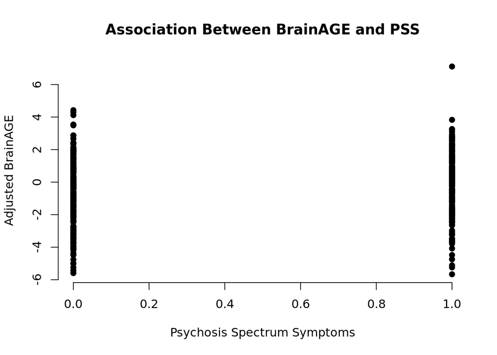

```r
# Plot the relationship between predicted age and PSS
plot(cleaned_filtered_data$prodromal_psychosis, cleaned_filtered_data$Adjusted_BrainAGE,
     main = "Association Between BrainAGE and PSS",
     xlab ="Psychosis Spectrum Symptoms", ylab = "Adjusted BrainAGE" ,
     pch = 19, frame = FALSE,)
```

Plot the variables of interest just to get an idea of what the data looks like

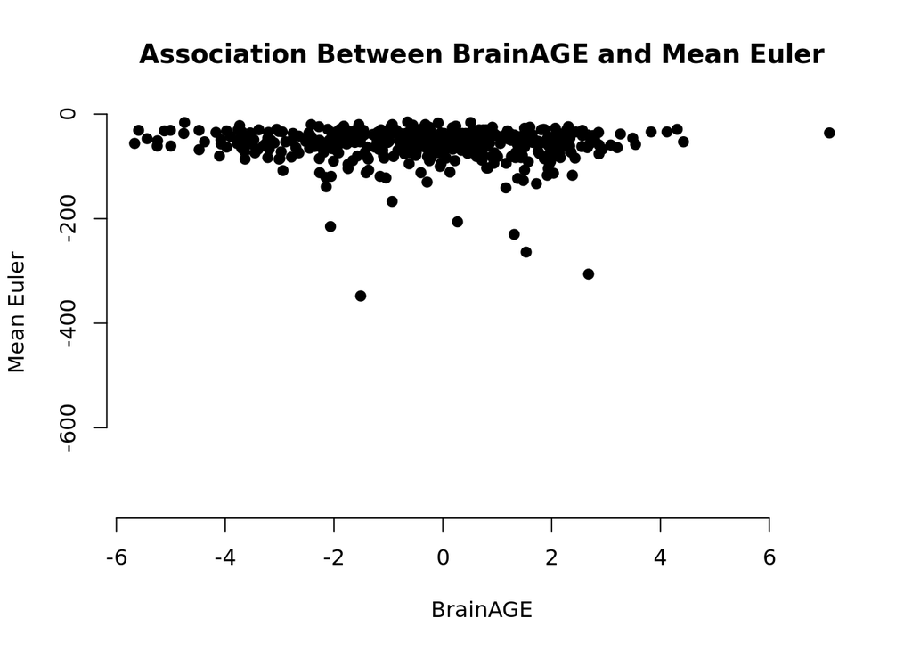

```r
# Plot the relationship between predicted age and Mean Euler (nothing removed)
plot(datacut_filtered_data$Adjusted_BrainAGE, datacut_filtered_data$mean_euler_bh,
     main = "Association Between BrainAGE and Mean Euler",
     xlab = "BrainAGE", ylab = "Mean Euler",
     pch = 19, frame = FALSE,)
```

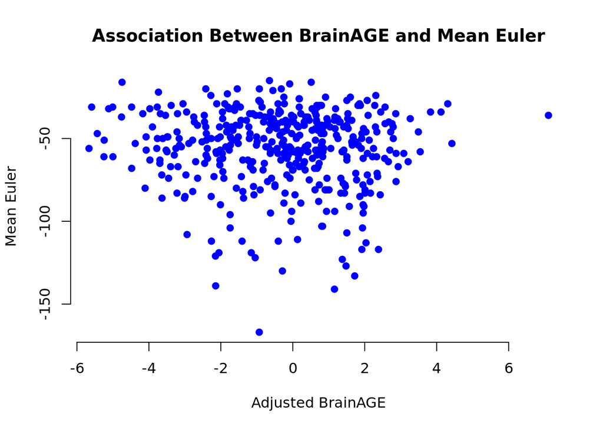

```r
# Plot the relationship between predicted age and Mean Euler with high euler removed
plot(cleaned_filtered_data$Adjusted_BrainAGE, cleaned_filtered_data$mean_euler_bh,
     main = "Association Between BrainAGE and Mean Euler",
     xlab = "Adjusted BrainAGE", ylab = "Mean Euler",
     pch = 19, frame = FALSE, col = "blue")
```

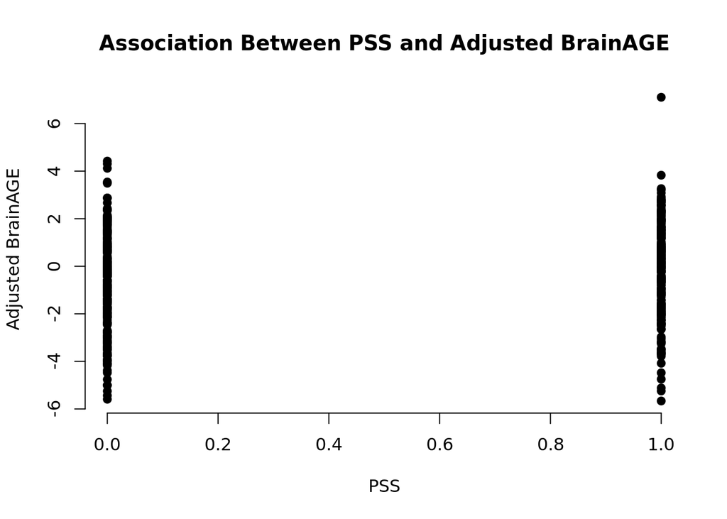

```r
# Plot the relationship between predicted PSS and Sex
plot(cleaned_filtered_data$prodromal_psychosis, cleaned_filtered_data$Adjusted_BrainAGE,
     main = "Association Between PSS and Adjusted BrainAGE",
     xlab = "PSS", ylab = "Adjusted BrainAGE",
     pch = 19, frame = FALSE,)
```

Calculate effect sizes

```r
effect_size <- cleaned_filtered_data %>%
  cohens_d(Adjusted_BrainAGE ~ prodromal_psychosis)

effect_size_pred_age <- cleaned_filtered_data %>%
  cohens_d(predicted_age ~ prodromal_psychosis)

# View the result
print(effect_size)
```

```
## # A tibble: 1 × 7
##   .y.               group1 group2 effsize    n1    n2 magnitude
## * <chr>             <chr>  <chr>    <dbl> <int> <int> <ord>
## 1 Adjusted_BrainAGE FALSE  TRUE    -0.259   204   214 small
```

```r
print(effect_size_pred_age)
```

```
## # A tibble: 1 × 7
##   .y.           group1 group2 effsize    n1    n2 magnitude
## * <chr>         <chr>  <chr>    <dbl> <int> <int> <ord>
## 1 predicted_age FALSE  TRUE    -0.127   204   214 negligible
```

Plot BrainAGE and PSS

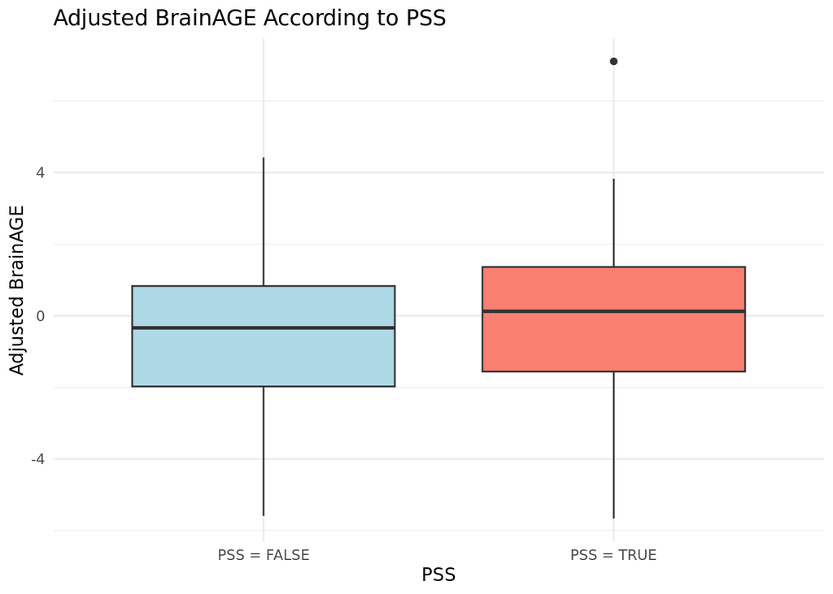

```r
# Create a box plot for brain age by PSS status
ggplot(cleaned_filtered_data, aes(x = factor(prodromal_psychosis, labels = c("PSS = FALSE", "PSS = TRUE")), y = Adjusted_BrainAGE)) +
  geom_boxplot(fill = c("lightblue", "salmon")) +  # Add color to the boxes
  labs(title = "Adjusted BrainAGE According to PSS",
       x = "PSS",
       y = "Adjusted BrainAGE") +
  theme_minimal()
```

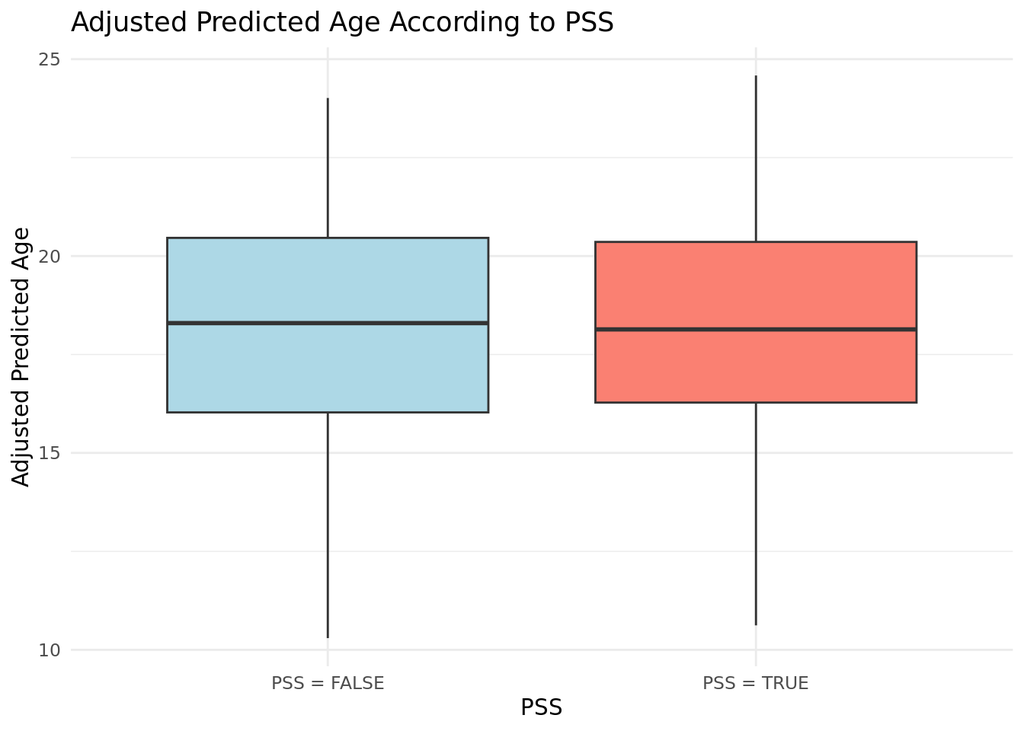

```r
# Create a box plot for predicted age by PSS status
ggplot(cleaned_filtered_data, aes(x = factor(prodromal_psychosis, labels = c("PSS = FALSE", "PSS = TRUE")), y = Adjusted_predicted_age)) +
  geom_boxplot(fill = c("lightblue", "salmon")) +  # Add color to the boxes
  labs(title = "Adjusted Predicted Age According to PSS",
       x = "PSS",
       y = "Adjusted Predicted Age") +
  theme_minimal()
```